# Prelab 2: Electric Forces, Fields, and Potentials Computational Lab

_Name:_Shikha Nukala

## Freebody Diagrams and Symmetry

In Part One, you will be investigating a physical system that is symmetric. This means that you could place a mirror in the center, and the image would still look the same. This could also be done by rotating about a central point, and having it look the same. The figure below is what you will see in lab. Do you see how by switching the two objects labeled M that the figure would look identical to the original? This means that it is symmetric about this central dotted line.

The balloons are charged and repel each other. The forces acting on each balloon are gravity, tnesion due to the strings, and the electric force.

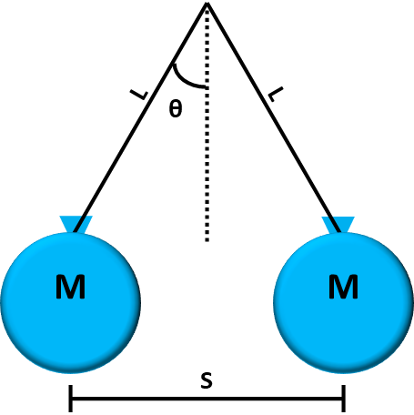

**Prelab Problem 2.1: How would you draw a free body diagram for the image above? Draw the free bodies diagrams for both balloons. Take a picture of your free body diagrams and upload them to your computer.**

An easy way to do this is if you took the picture with a smartphone, email the picture to yourself and then pull up your email on your computer and download the photo.

Once the picture is on your computer, copy and paste the photo into the cell below. Then run the cell. Your image should appear.

[figure not shown]

In the lab, you will be using code to create the free body diagrams. To do this with accurate magnitudes, you will need to calculate the charges on each of the balloons.

## Circular Motion

In Part Two, you will dive directly into the parallels between Newton’s laws of gravitation and Coulomb’s law. More specifically, you will be looking at how Coulomb’s law can also give rise to orbits! Thus, it will be helpful for you to do a quick revision of circular motion. Recall that for circular motion $a_{c} = v^2/r$ where $a_c$ is the centripetal acceleration, $v$ is the speed of the orbiting body, and $r$ is the radius of the orbit. Refer to the figure below for the next problem.

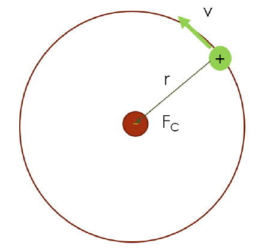

**Prelab Problem 2.2: Assuming you have a positive charge with charge $q$ and mass $m$ orbiting a negative one with charge $Q$ and mass $M$ in circular motion at a radius $r$, calculate the speed $v$ of the positive charge. We assume $m<<M$ and that the electric force is must stronger than gravity, so that your calculations exclude the force of gravity. Provide your answer in terms of $q$, $m$, $Q$, $M$, $r$, and any known constants (such as $k$ or $\epsilon_{0}$) and please try to write your answer using LaTex in the space below.**

$v =$ $\sqrt{\frac{k q Q}{m r}}$

## Electric Potential

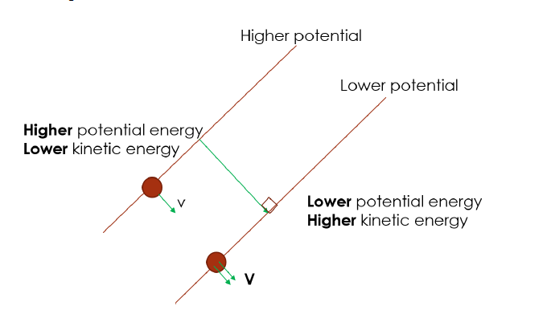

In Lab 1, you were introduced to the concept of electric fields and electric potentials. In this lab, you will be exploring them from the perspective of energy, and how you can use equipotential lines to predict the behavior of a charged particle.

Potential energy is a rather abstract concept, and it is often defined as the energy of an object due to its position in space. You can think of the potential energy of an object as how much kinetic energy the object could potentially have, barring any loss to frictional forces. An object moving from higher to lower potential energy will gain kinetic energy in the process, and thus move faster. Note also the green field arrow near the center of the figure above, making a 90 degrees angle with the equipotential lines. The direction of the field arrow tells us the direction of the force on the object, and thus the direction of the acceleration. *Will an object always move in the direction of the field arrows?*

Pause here for a moment and look back to the previous paragraph. Do you realize there was not a single use of the word ‘electric’? We could have thrown the word ‘gravitational’ in and it would still be correct! Except that for electric potential, we must specify if the charge is positive or negative. The statements in the above paragraph are accurate for electric potentials if the charge is positive. Negative charges will have the exact opposite behavior.

**Prelab Problem 2.3: Absent other forces, will a particle always accelerate in the direction of an electric field? If not, provide an example of a situation where this is not the case.**

No not always. The force from an electric field is F = qE and F = ma so a = qE/m. Therefore if q is greater than 0 acceleration is in the same direction as the electric field but if it is less than 0 acceleration is opposite to the electric field. So an example is if an electron is placed in a uniform electric field it will accelerate in the opposite direction to the field vector.

A major goal of this lab is to build your intuition for understanding electric potentials and fields using gravity as an analogy. There are several parallels between the two, including what was mentioned in the previous section. At the end of this lab, you should be able to make predictions on the behavior of a charged particle through an electric potential map. Hint: It is not too different from an object with mass moving through a contour map!

### You're done! Submit your pre-lab per the following instructions.

- Save an html version of this file with the pre-lab number and your uniqname to submit to canvas, e.g. `prelab02_bhipsley.html`. If you are woking in Jupyter, you can do this by opening the `File` tab on the top left corner of Jupyter, then select `Save and Export Notebook as > HTML (.html)`.
- If you are working in Google Colab, first open the `File` tab on the top left corner of Google Colab and select `Download > Download .ipynb` to save the editted file in .ipynb format. Then click `Ctrl-P` (Windows) or `Cmd-P` (Mac) to save the notebook in .pdf format.
- Submit **both** the .ipynb and .html (or **both** the .ipynb and .pdf) files to canvas under the `Pre-Lab 2: Electric Fields Computational Lab` assignment.